#Project title: Project 9 #Name: Sweta Kumari #Assignment: Lung Capacity Dataset

#Read the Lung Capacity Dataset.

```r
LuCa<-read.csv("C:\\Users\\Sweta\\Documents\\Data\\LungCapData.csv", header=T)
attach(LuCa)
names(LuCa)
```

```
## [1] "Age"     "LungCap" "Height"  "Gender"  "Smoke"
```

#Summary of the dataset

```r
summary(LuCa)
```

```
##       Age            LungCap           Height         Gender    Smoke
##  Min.   : 3.000   Min.   : 0.373   Min.   :46.00   female:318   no :589
##  1st Qu.: 8.000   1st Qu.: 3.943   1st Qu.:57.00   male  :336   yes: 65
##  Median :10.000   Median : 5.643   Median :61.50
##  Mean   : 9.931   Mean   : 5.910   Mean   :61.14
##  3rd Qu.:12.000   3rd Qu.: 7.356   3rd Qu.:65.50
##  Max.   :19.000   Max.   :15.379   Max.   :74.00
```

#Box plot for Gender vs Lung Cap

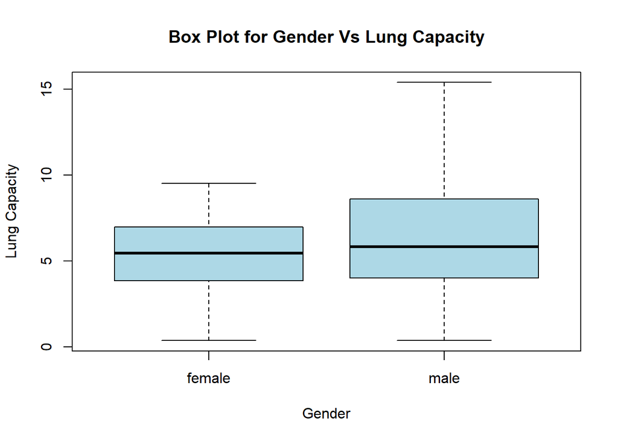

```r
plot(Gender,LungCap, ylab="Lung Capacity",xlab="Gender", main="Box Plot for Gender Vs Lung Capacity", col='lightblue')
```

#Scatter plot for Height vs Lung Capacity

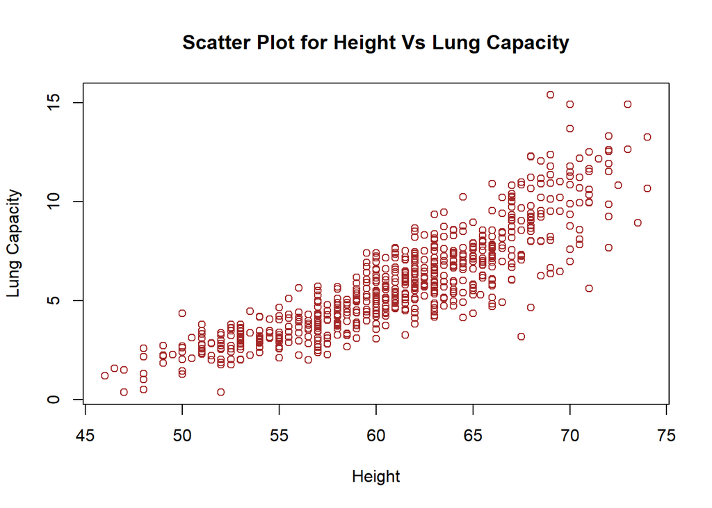

```r
plot(Height,LungCap, ylab="Lung Capacity",xlab="Height", main="Scatter Plot for Height Vs Lung Capacity", col='brown')
```

#Scatter plot for Age vs Lung Capacity

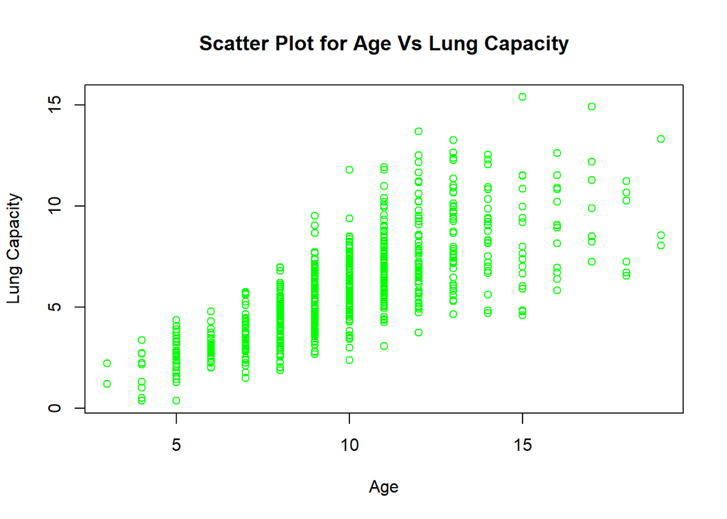

```r
plot(Age,LungCap, ylab="Lung Capacity",xlab="Age", main="Scatter Plot for Age Vs Lung Capacity", col='green')
```

#Box plot for Smoke vs Lung Capacity

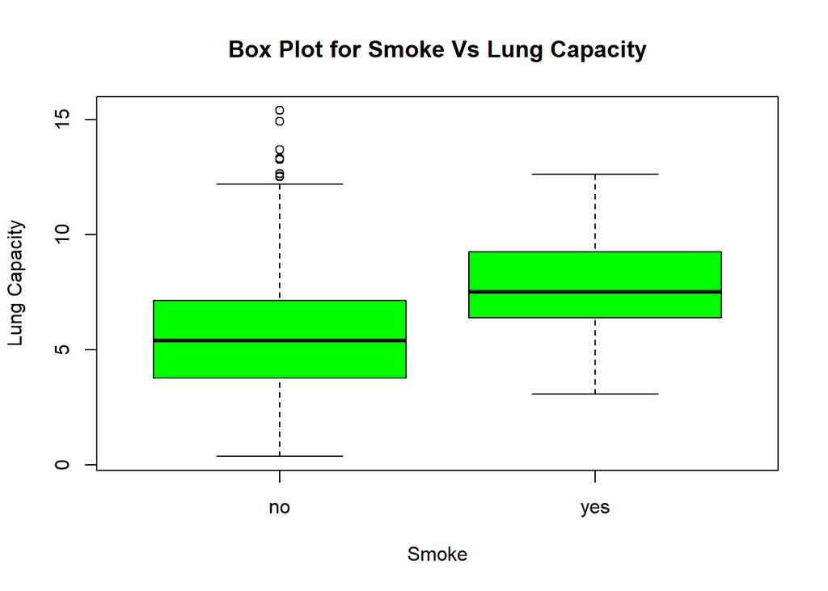

```r
plot(Smoke,LungCap, ylab="Lung Capacity",xlab="Smoke", main="Box Plot for Smoke Vs Lung Capacity", col='green')
```

#Histogram for Lung Capacity

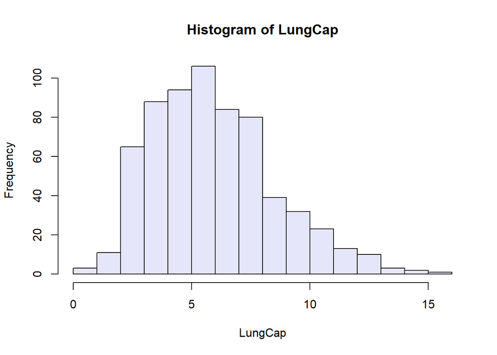

```r
hist(LungCap, col = "lavender")
```

#Histogram for Age

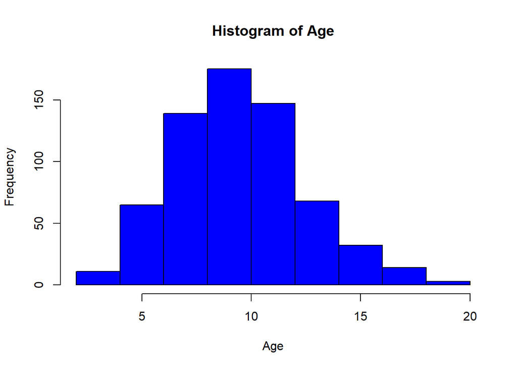

```r
hist(Age, col = "blue")
```

#Histogram for Height

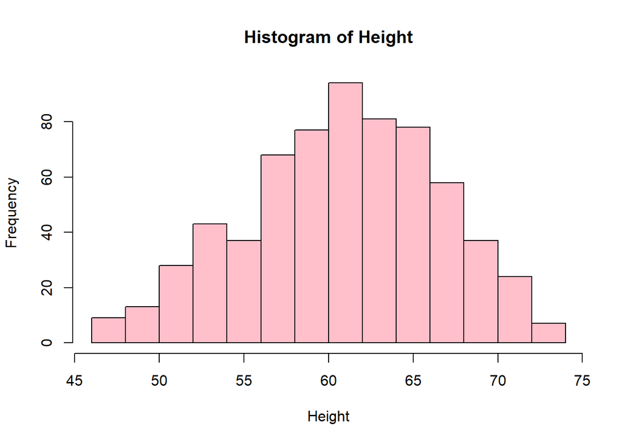

```r
hist(Height, col="pink")
```

#Average Lung Capacity in female and male.

```r
tapply(LungCap,Gender,mean)
```

```
##   female     male
## 5.353509 6.437339
```

#Average Lung Capacity for smoker and non-smoker.

```r
tapply(LungCap,Smoke,mean)
```

```
##       no      yes
## 5.698428 7.830585
```

#Average Lung Capacity for different age.

```r
tapply(LungCap,Age,mean)
```

```
##         3         4         5         6         7         8         9
##  1.714000  1.827667  2.656857  2.973919  3.608333  4.345918  5.296511
##        10        11        12        13        14        15        16
##  6.070407  7.118033  7.670316  8.449767  8.746720  8.454526  9.006769
##        17        18        19
## 10.889500  8.775500  9.966000
```

#Average Lung Capacity for different Height.

```r
tapply(LungCap,Height,mean)
```

```
##        46      46.5        47        48        49      49.5        50
##  1.216000  1.588000  0.941500  1.522000  2.257750  2.275000  2.404000
##      50.5        51      51.5        52      52.5        53      53.5
##  2.608000  2.894500  2.481250  2.470250  2.930500  3.017833  3.363000
##        54      54.5        55      55.5        56      56.5        57
##  3.167500  3.379500  3.203800  3.813571  3.824333  3.453667  4.029308
##      57.5        58      58.5        59      59.5        60      60.5
##  3.651727  4.339545  4.066250  4.791571  5.547357  5.439200  5.322500
##        61      61.5        62      62.5        63      63.5        64
##  5.837500  5.796182  6.243300  6.385000  6.289273  6.765769  6.631522
##      64.5        65      65.4      65.5        66      66.5        67
##  7.002053  6.865000  5.302000  7.272471  7.130500  7.991000  8.694100
##      67.5        68      68.5        69      69.5        70      70.5
##  7.973500  9.282294  9.467364 10.066545  9.297250 10.592364  9.791714
##        71      71.5        72      72.5        73      73.5        74
## 10.265500 12.160000 11.082625 10.816000 13.765000  8.935000 11.962000
```

#Lung Capacity is higher for male than female.If Height or Age increases, Lung Capacity also increases.Lung Capacity is higher for smoker than non-smoker.Height and Age data is normally distributed while distribution of Lung Capacity is data is slighlty right skewed.

#Model1

#R square is 0.754. p-value is less than the significance level(=0.05). #The correlation between the Lung Capacity and Height is statistically significant

```r
model1<-lm(LungCap ~ Height)
summary(model1)
```

```
##
## Call:
## lm(formula = LungCap ~ Height)
##
## Residuals:
##     Min      1Q  Median      3Q     Max
## -5.2550 -0.7986 -0.0120  0.7342  6.3581
##
## Coefficients:
##               Estimate Std. Error t value Pr(>|t|)
## (Intercept) -18.298036   0.544380  -33.61   <2e-16 ***
## Height        0.395927   0.008865   44.66   <2e-16 ***
## ---
## Signif. codes:  0 '***' 0.001 '**' 0.01 '*' 0.05 '.' 0.1 ' ' 1
##
## Residual standard error: 1.292 on 652 degrees of freedom
## Multiple R-squared:  0.7537, Adjusted R-squared:  0.7533
## F-statistic:  1995 on 1 and 652 DF,  p-value: < 2.2e-16
```

#Model2

#R square is 0.774 which is higher than model1. Hence more variation can be explianed by the model2.p-value is zero which is lower than the significance level(=0.05) #The correlation between Lung Capacity and Height is statistically significant.

```r
model2 <- lm(formula = LungCap ~ Height + I(Height**2))
summary(model2)
```

```
##
## Call:
## lm(formula = LungCap ~ Height + I(Height^2))
##
## Residuals:
##     Min      1Q  Median      3Q     Max
## -5.4031 -0.6878 -0.0076  0.6577  5.9910
##
## Coefficients:
##              Estimate Std. Error t value Pr(>|t|)
## (Intercept) 16.080634   4.509553   3.566 0.000389 ***
## Height      -0.750147   0.149566  -5.015 6.83e-07 ***
## I(Height^2)  0.009466   0.001233   7.675 6.07e-14 ***
## ---
## Signif. codes:  0 '***' 0.001 '**' 0.01 '*' 0.05 '.' 0.1 ' ' 1
##
## Residual standard error: 1.238 on 651 degrees of freedom
## Multiple R-squared:  0.7741, Adjusted R-squared:  0.7734
## F-statistic:  1115 on 2 and 651 DF,  p-value: < 2.2e-16
```

#Model3

#R square is 0.774 which is same as model2. But, p-value is higher than the significance level(=0.05).Hence, model3 do not have significant predictors.

```r
model3 <- lm(formula = LungCap ~ Height + I(Height**2) + I(Height**3))
summary(model3)
```

```
##
## Call:
## lm(formula = LungCap ~ Height + I(Height^2) + I(Height^3))
##
## Residuals:
##     Min      1Q  Median      3Q     Max
## -5.3885 -0.6900  0.0069  0.6511  5.9936
##
## Coefficients:
##               Estimate Std. Error t value Pr(>|t|)
## (Intercept) -6.293e-01  3.803e+01  -0.017    0.987
## Height       9.179e-02  1.908e+00   0.048    0.962
## I(Height^2) -4.567e-03  3.173e-02  -0.144    0.886
## I(Height^3)  7.739e-05  1.749e-04   0.443    0.658
##
## Residual standard error: 1.239 on 650 degrees of freedom
## Multiple R-squared:  0.7742, Adjusted R-squared:  0.7731
## F-statistic: 742.7 on 3 and 650 DF,  p-value: < 2.2e-16
```

#Compare Model1 and Model2

#p-value is less than the alpha (significance level=0.05), adding Height^2 has significantly improved the fit over model1.F value is high which says model2 is significant over model1.

```r
anova(model1,model2)
```

```
## Analysis of Variance Table
##
## Model 1: LungCap ~ Height
## Model 2: LungCap ~ Height + I(Height^2)
##   Res.Df     RSS Df Sum of Sq      F    Pr(>F)
## 1    652 1088.41
## 2    651  998.09  1    90.314 58.907 6.069e-14 ***
## ---
## Signif. codes:  0 '***' 0.001 '**' 0.01 '*' 0.05 '.' 0.1 ' ' 1
```

#Compare Model2 and Model3

#p-value is more than the alpha (significance level=0.05), adding Height^3 has not significantly improved the fit over model2.F value is low which says model3 is not significant over model2.

```r
anova(model2,model3)
```

```
## Analysis of Variance Table
##
## Model 1: LungCap ~ Height + I(Height^2)
## Model 2: LungCap ~ Height + I(Height^2) + I(Height^3)
##   Res.Df    RSS Df Sum of Sq      F Pr(>F)
## 1    651 998.09
## 2    650 997.79  1   0.30066 0.1959 0.6582
```

#Fit the regreesion line for model1

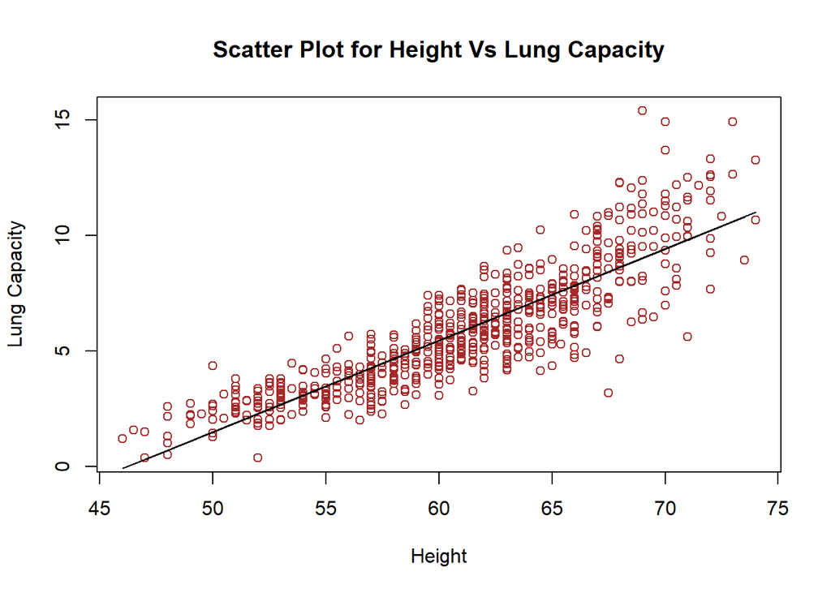

```r
plot(Height,LungCap, ylab="Lung Capacity",xlab="Height", main="Scatter Plot for Height Vs Lung Capacity", col='brown')
points(Height, predict(model1), type="l", col="black")
```

#Fit the regreesion line for model2

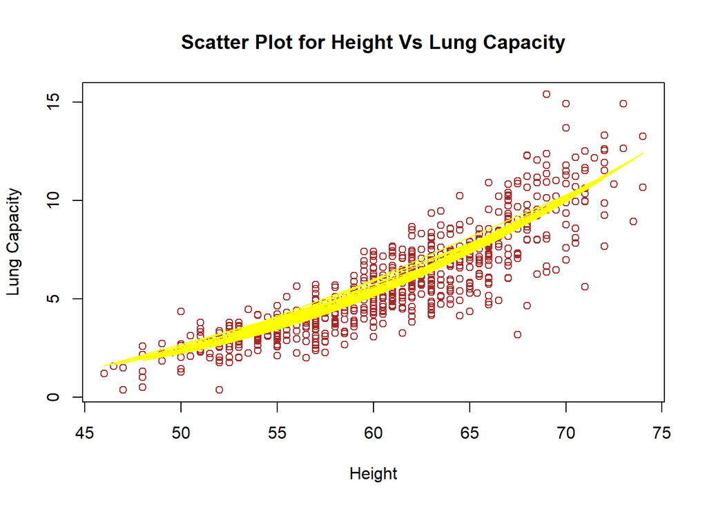

```r
plot(Height,LungCap, ylab="Lung Capacity",xlab="Height", main="Scatter Plot for Height Vs Lung Capacity", col='brown')
points(Height, predict(model2), type="l", col="yellow")
```

#Fit the regreesion line for model3

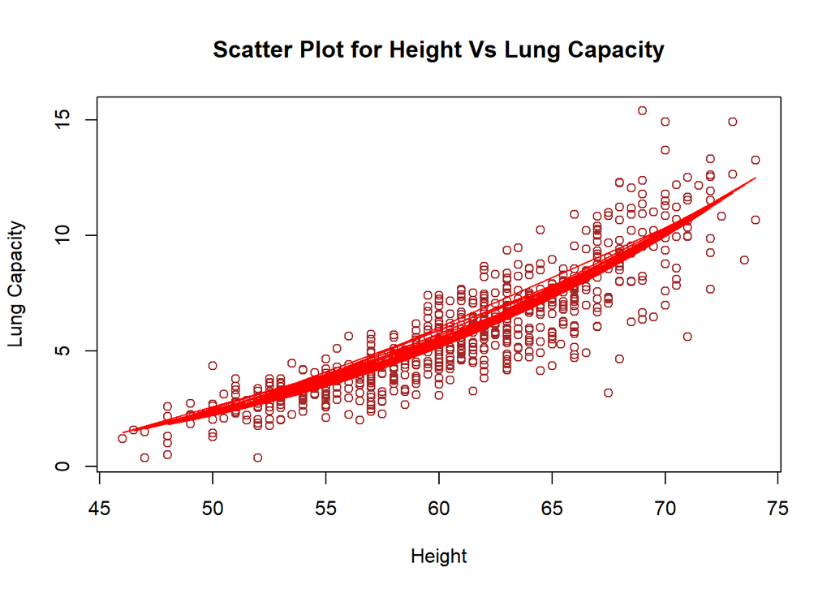

```r
plot(Height,LungCap, ylab="Lung Capacity",xlab="Height", main="Scatter Plot for Height Vs Lung Capacity", col='brown')
points(Height, predict(model3), type="l", col="red")
```

#Plot all regression line in one graph

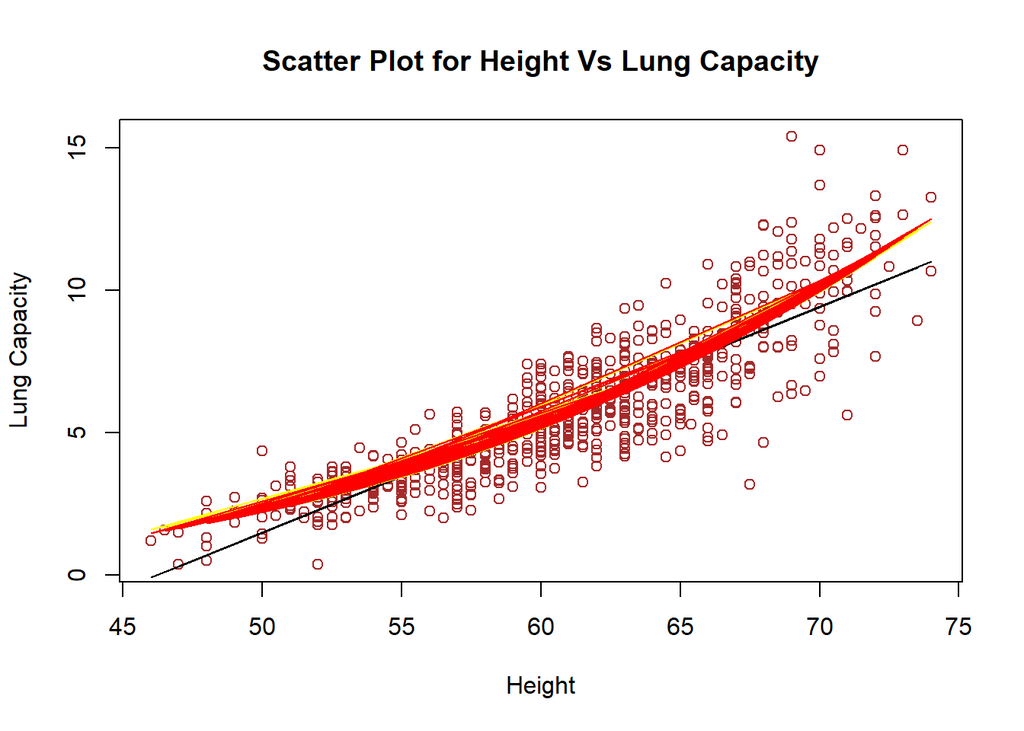

```r
plot(Height,LungCap, ylab="Lung Capacity",xlab="Height", main="Scatter Plot for Height Vs Lung Capacity", col='brown')
points(Height, predict(model1), type="l", col="black")
points(Height, predict(model2), type="l", col="yellow")
points(Height, predict(model3), type="l", col="red")
```

#Predict the Lung capacity for model1

```r
predict(model1,list(Height=60))
```

```
##        1
## 5.457566
```

#Predict the Lung capacity for model2

```r
predict(model2,list(Height=60))
```

```
##        1
## 5.149344
```

#Predict the Lung capacity for model3

```r
predict(model3,list(Height=60))
```

```
##        1
## 5.154175
```

#Conclusion:

#1. Model2 has higher R square than Model1. R square is same for model2 and model3. #2. Model1 and Model2: p-value is less than the significance level(=0.05) which shows that both model have significant predictors. #3. Model3: p-value is higher than the significance level(=0.05) which shows that model3 does not have significant predictors. #4. Anova comparison: Model2 is significant over model1. But, model3 is not significant over model2. #5. Quadratic model is preferred over the linear model but not a cubic model over the quadratic model.